# Homework Week 5

Daphne Ezer

2024-01-29

## Tasks to do before next class

Instructions for how to do these tasks is on the VLE under Week1

1. Practice fetching the latest version of the project from Github
2. Download your dataset from the Google Drive and put it in the data folder of your R Project
3. Add a personal script in the dev folder that includes information from this Tutorial.
4. Push your script to the Github project (but do NOT add the data file!)
5. Add necessary information to the Google slide.

Yellow boxes highlight the information that you should add to you team’s Google slide deck for next week.

Blue boxes highlight additional activities that you could do that might enhance the class project. Outputs of this could be made into functions for the class coding library.

## Aims for today

Explore the network that you developed last week:

- What is the overlap between the new network and the old AraBOXcis network?
- What genes play an important role within the network?
- What are the associations between GO terms within the network?

## Load the network

```r
a=load('flower_network_nTree_5.RData') ### Remember to actually load in your specific network and to use the network that has 1000 trees
newNet=GENIE3::getLinkList(net)
araboxcis=read.csv('data/gboxNetwork22C.csv', header=T)
```

## Find overlaps between the single cell gene network and the AraBOXcis network

```r
#gets the set of unique genes in your new network
genesInNet=unique(c(newNet[,1], newNet[,2]))

#filter the AraBOXcis network to only contain genes that are in your new network
araboxcisFiltered=araboxcis[which(araboxcis[,1] %in% genesInNet & araboxcis[,2] %in% genesInNet),]

#extract the top edges in your new network, to make your network the same size as the araboxcisFiltered network.
newNetTopEdges=newNet[1:length(araboxcisFiltered[,1]),]

#reformat edges so it is more straightforward to compare them
edgesNew=paste(newNetTopEdges[,1], newNetTopEdges[,2], sep='_')
edgesOld=paste(araboxcisFiltered[,1], araboxcisFiltered[,2], sep='_')

#Now, you can come up with all the different parts of a Venn Diagram:

#The overlap
length(which(edgesNew %in% edgesOld))
```

```
## [1] 8265
```

```r
#In new network only
length(which(! (edgesNew %in% edgesOld)))
```

```
## [1] 36531
```

```r
#In old network only
length(which(! (edgesOld %in% edgesNew)))
```

```
## [1] 36531
```

Using circles in the Google Drive Slides, make a Venn Diagram that summarises this information. Make sure that it is obvious which developmental stage this is refering too.

Can you use a similar strategy to make Venn Diagrams to compare the networks from other members of your Team?

Let’s take a moment to self-reflect. When I see a Venn Diagram like this, this is the thought process that goes through my mind: The total number of possible edges is going to be (number of TFs) * (number of genes), which for flowers is about 282,472 edges. Here, we selected the top 44796 edges, which represents the top 15.8% of edges. Since it will be roughly the same for AraBOXcis, you would expect an overlap of around 0.158*0.158*282,472, which is around 7052. We have more overlap than what we expect, but it isn’t drastically more (about 17% higher). However, I made this Workshop using the network built on 5 trees, so it may be higher. Also, flowers are about as distinct from seedlings in terms of biology as you can get, so it would be strange if these networks were extremely overlapping.

## Find important genes in the network

There are different ways of finding important genes in the network, such as identifying well-connected hubs (hub_score), finding influential/central genes (alpha centrality), and finding genes that bridge between different regions in the network (betweenness). Here, we’ll calculate all three, but first let’s crudely look to see which transcription factors (TFs) have the most edges (called their ‘degree’) and compare degrees in the old AraBOXcis network and our new one.

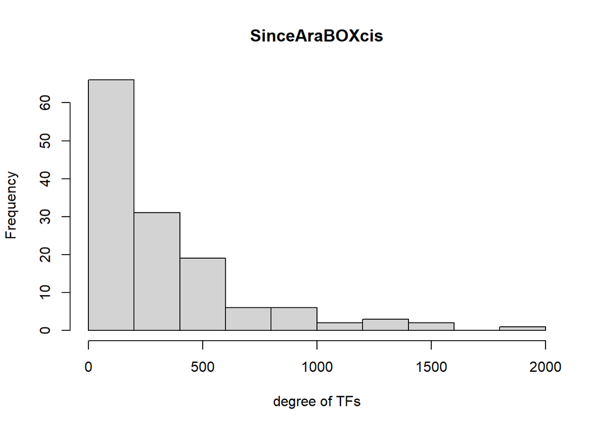

```r
tfsNew=table(newNetTopEdges[,1])
tfsOld=table(araboxcisFiltered[,1])[names(tfsNew)]

#histogram of degrees should look like an exponential distribution, because biological networks are a kind of network called 'scale-free', meaning that most TFs only regulate a small number of genes, but a few are influential hubs.

hist(as.numeric(tfsNew), main='SinceAraBOXcis', xlab='degree of TFs')
```

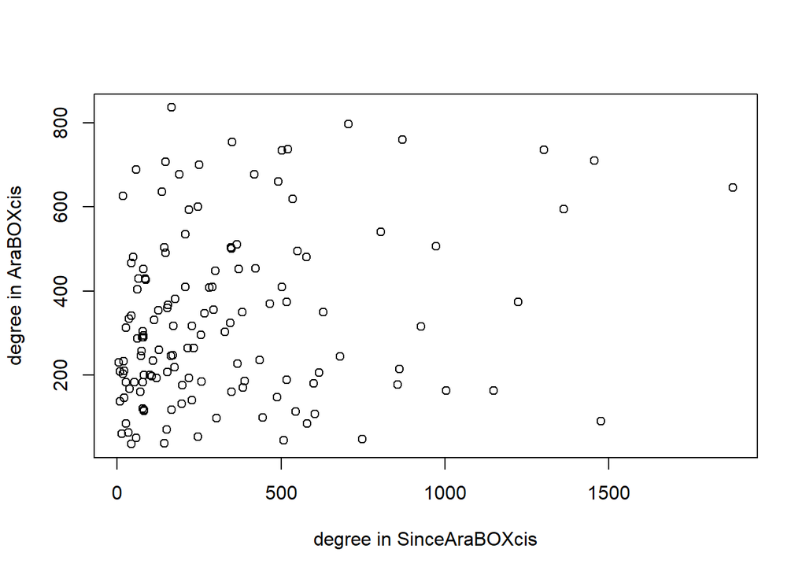

```r
#Let's see if the same TFs have high degrees in AraBOXcis and our new network:
plot(as.numeric(tfsNew), as.numeric(tfsOld), xlab='degree in SinceAraBOXcis', ylab='degree in AraBOXcis')
```

```r
#Let's print out the 20 TFs with highest degrees.
sort(tfsNew, decreasing=TRUE)[1:20]
```

```
##
## AT5G08130 AT3G24140 AT3G57800 AT5G54680 AT3G17100 AT3G58120 AT1G59640 AT1G03970
##      1878      1475      1455      1362      1302      1223      1148      1004
## AT4G36540 AT1G32640 AT4G36730 AT1G10120 AT2G43010 AT4G34000 AT2G42300 AT5G46760
##       972       927       870       862       855       804       748       705
## AT1G05805 AT3G59060 AT2G46810 AT3G23690
##       681       628       616       604
```

Whenever you find a small set of genes that seem interesting, you can look up their biological roles using arabidopsis.org. There is a search bar at the top that let’s you search the gene ID. Are any of these genes relevant for the developmental stage you are investigating? Particularly, take a close look at the eFP browser tool that is embedded on arabidopsis.org. Is the gene expressed in your developmental stage?

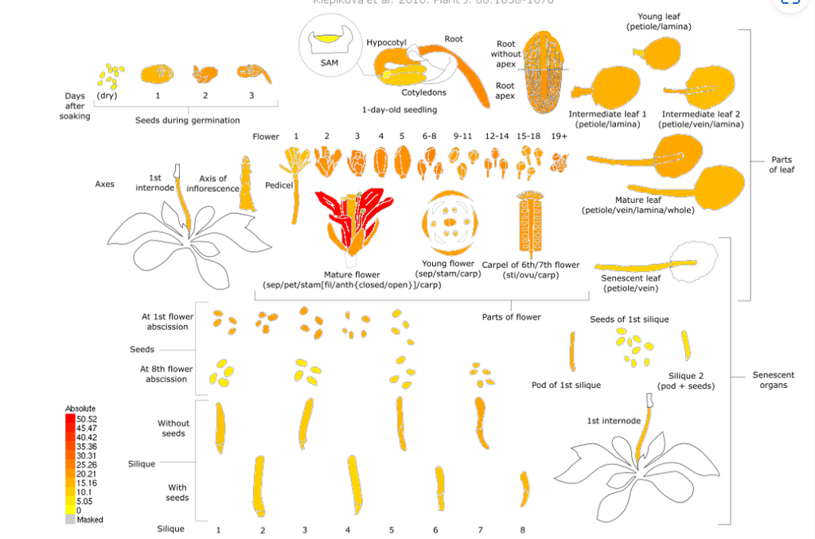

Here is a picture of what I mean by the eFP browser tool.

Now, let’s calculate all the different metrics of TF importance. Make sure to look up the definitions of these three different metrics and then look up the individual names of genes that rank highly by these metrics on arabidopsis.org. Here, I’m giving you a rough idea of what to do, but by this stage, I’d expect you to know how to rename x- and y-axis to be sensible.

```r
library(igraph)
library(network)
library(pheatmap)
simple_network <- graph_from_edgelist(as.matrix(newNetTopEdges[,c(1,2)]))

node_betweenness_all <- betweenness(simple_network)
node_betweenness=node_betweenness_all[which(node_betweenness_all>0)]
sort(node_betweenness, decreasing=TRUE)[1:20]
```

```
## AT2G46810 AT4G02640 AT3G54620 AT1G51140 AT3G61950 AT5G57150 AT3G23210 AT3G07340
##  7010.451  6819.833  6382.257  6337.627  5825.599  5277.952  5157.560  5128.635
## AT4G09180 AT3G19290 AT5G49450 AT1G03970 AT2G27230 AT4G29100 AT5G54680 AT2G43010
##  4986.990  4648.127  4617.090  4519.425  4515.097  4487.462  4459.706  4443.346
## AT2G35530 AT3G59060 AT3G58120 AT5G24800
##  4388.597  4241.168  4235.471  4219.975
```

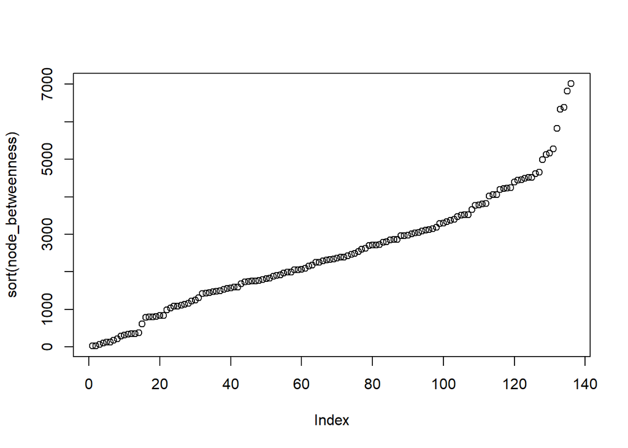

```r
plot(sort(node_betweenness))
```

```r
#abline(h=5000)

node_centrality_all <- alpha_centrality(simple_network)
node_centrality=node_centrality_all[which(node_centrality_all>0)]
sort(node_centrality, decreasing=TRUE)[1:20]
```

```
## AT3G05160 AT1G15215 AT1G31710 AT4G29420 AT5G53290 AT3G51470 AT2G26040 AT2G44660
## 14.207618 14.132378 13.290629 13.260455 12.983757 12.704001 12.140028 11.714388
## AT5G41810 AT4G18360 AT5G57785 AT1G19080 AT1G55190 AT3G52105 AT5G63500 AT5G50335
## 11.314090 11.148552 10.993421 10.704511 10.442340 10.025165 10.020819  9.813257
## AT2G46230 AT2G42940 AT3G57860 AT3G57560
##  9.324796  9.165158  8.836306  8.682284
```

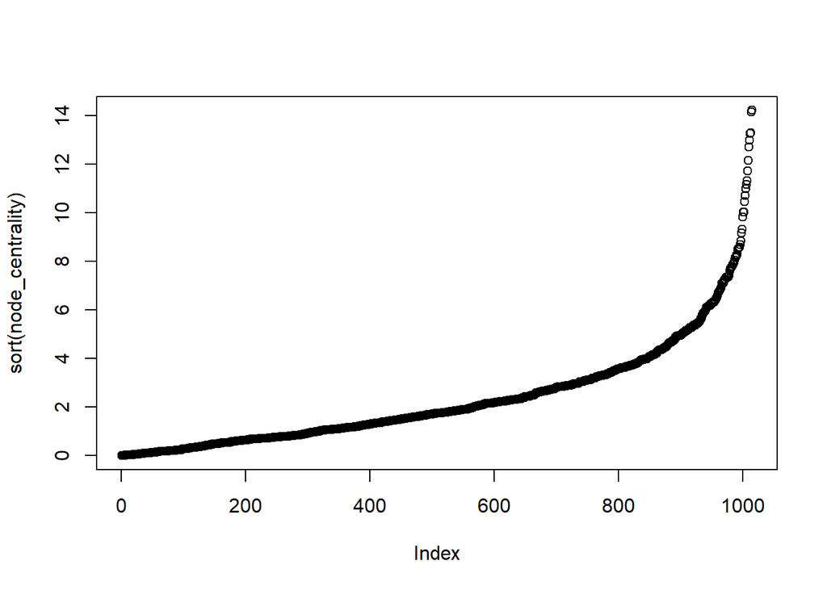

```r
plot(sort(node_centrality))
```

```r
#abline(h=5000)

node_hub_all <- hub_score(simple_network)$vector
node_hub=node_hub_all[which(node_hub_all>0)]
sort(node_hub, decreasing=TRUE)[1:20]
```

```
## AT5G08130 AT3G24140 AT3G57800 AT5G54680 AT3G17100 AT3G58120 AT1G59640 AT1G03970
## 1.0000000 0.7952885 0.7879938 0.7313909 0.7051830 0.6612146 0.6203257 0.5439566
## AT4G36540 AT1G32640 AT1G10120 AT4G36730 AT2G43010 AT4G34000 AT2G42300 AT5G46760
## 0.5277541 0.5065476 0.4691391 0.4689676 0.4685679 0.4361867 0.4015028 0.3860834
## AT1G05805 AT3G59060 AT2G46810 AT3G23690
## 0.3697409 0.3399716 0.3346182 0.3260911
```

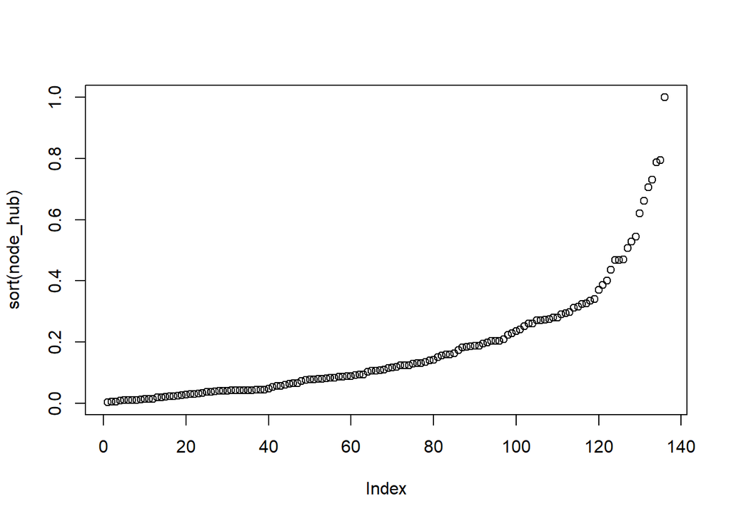

```r
plot(sort(node_hub))
```

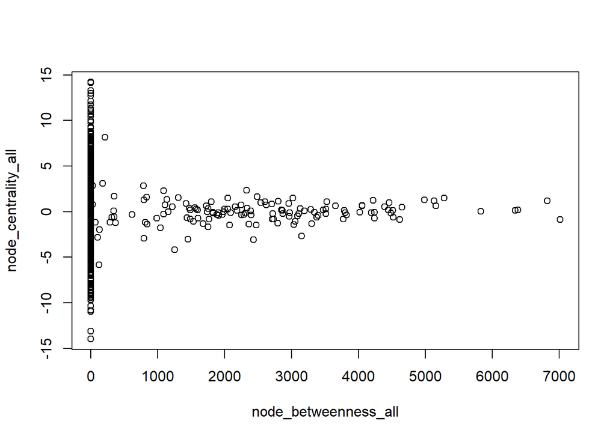

```r
#abline(h=0.6)

plot(node_betweenness_all, node_centrality_all)
```

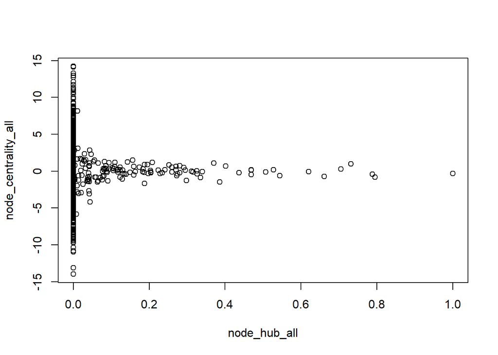

```r
plot(node_hub_all, node_centrality_all)
```

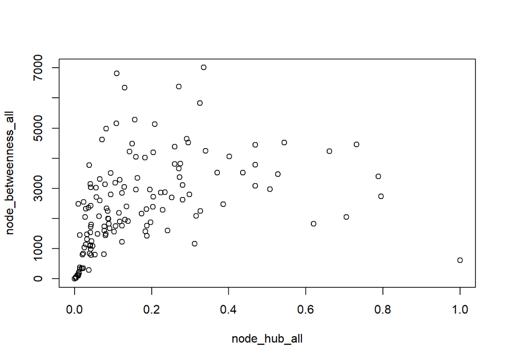

```r
plot(node_hub_all, node_betweenness_all)
```

You should put something from this section into the Google Drive, whether it is a spreadsheet of all of the important genes in the network, based on all these different criteria or some scatterplot or a paragraph describing the biological function of some key genes or a combination of these. By this stage, I’m giving you independence to decide what you think is important. You might want to discuss your choices with your teammates.

## Find associations between GO terms in the network

These big networks are sometimes difficult to interpret. One way to make sense of it is to find out whether there are certain GO terms that occur upstream or downstream of other GO terms in the network. To do this, we use the statistical tool PAFway that a masters student developed in my lab a few years ago. I added code for this (faster than the published version) in dataprocessingHelperFunctions.R. Please make sure you have fetched the latest copy of the SinceArabidopsis project from Github!

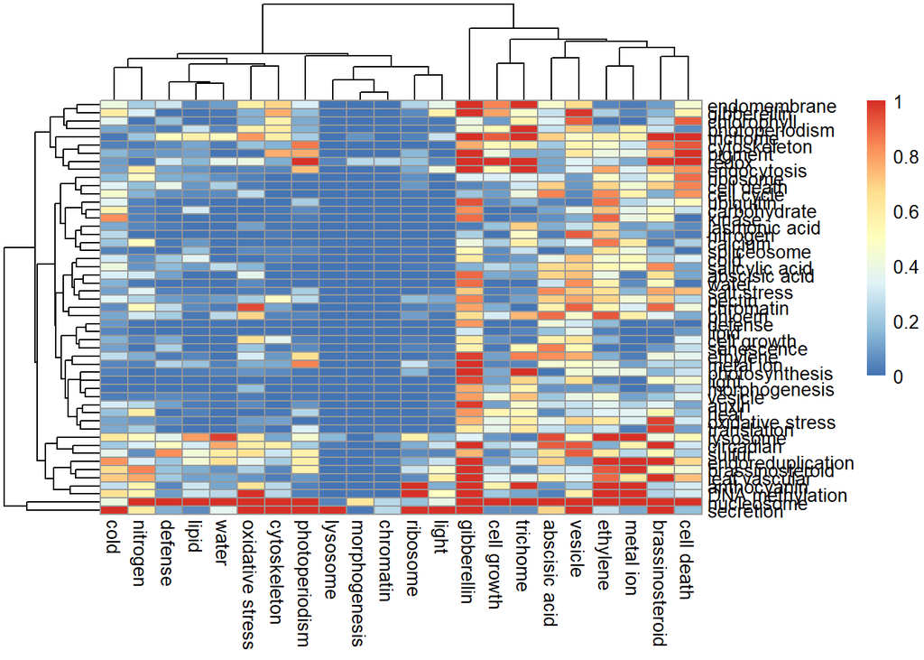

```r
a=load('data/functionalData.RData')
source('dev/utilities/dataprocessingHelperFunctions.R')

pafwayOut=pafway(GOconcat, newNetTopEdges, unique(goOfInterest))
rownames(pafwayOut)=colnames(pafwayOut)

#Filter to only include rows and columns with at least one significant factor:
atLeastOneSigRow=which(apply(pafwayOut, 1, function(i){length(which(i<0.05))})>0)


atLeastOneSigCol=which(apply(pafwayOut, 2, function(i){length(which(i<0.05))})>0)

pafwayInterestingOnly=pafwayOut[atLeastOneSigRow, atLeastOneSigCol]

#Here, the terms associated with the columns are upstream of the terms associated with the rows.  The values correspond to p-values, so smaller is more significant.
pheatmap(pafwayInterestingOnly)
```

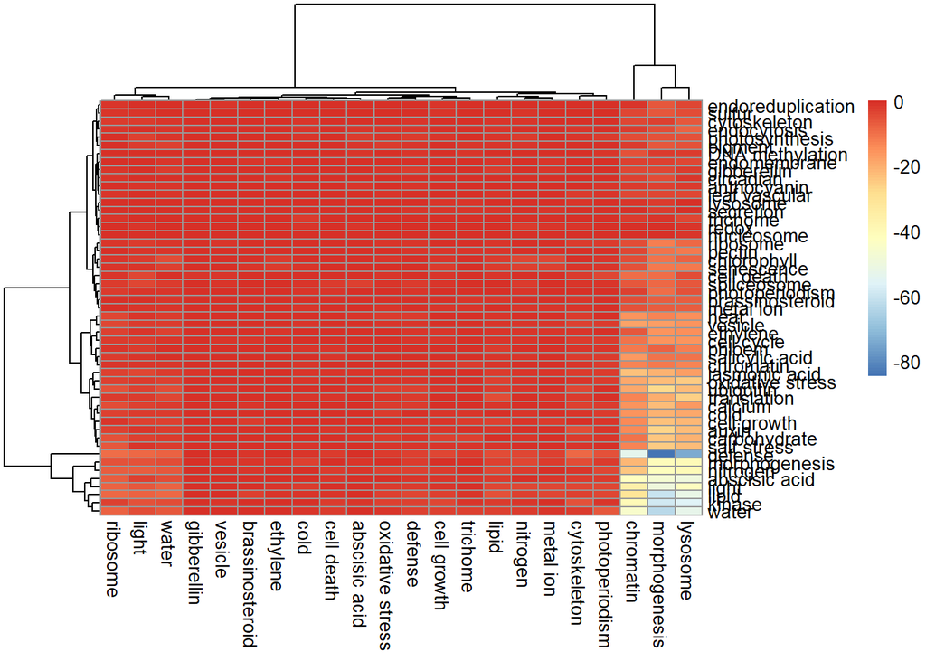

```r
#Let's re-do zooming to the most significant associations by taking a log
pheatmap(log(pafwayInterestingOnly, 10))
```

Put these heatmaps on your slide deck. Do these make any biological sense? Are they consistent across your team?

## Takeaways and Future Steps

At this point, you should start to identify what you envision your ‘biological story’ to be. Discuss in your groups what you want to write your reports about. You could focus on your results, but you are more than welcome to also include results from your Teammates or the class.

You may want to consider how to visualise the network. One way to do this is with programmes such as Cytoscape. I would explore these programmes, especially considering ‘force-layouts’ and ‘hierarchical layouts’.